# 波尔多葡萄酒分析报告

周慧盈

## 项目背景

本项目基于波尔多红酒销售交易数据，对客户购买行为进行统计分析。 通过探索性数据分析与统计检验方法，研究不同客户群体在消费行为、 产品选择以及促销策略响应上的差异，为红酒营销策略制定提供数据支持。

## 数据说明

数据包含三张表：

- customers：客户信息
- products：红酒产品信息
- transactions：销售交易数据

主要字段：

- customer_id
- product_id
- order_amount
- quantity
- purchase_date
- segment

##数据读取和准备

```r
library(tidyverse)
library(lubridate)

customers <- read.csv("E:/projet/wine/data/customers.csv")
products <- read.csv("E:/projet/wine/data/products.csv")
transactions <- read.csv("E:/projet/wine/data/transactions.csv")

transactions$purchase_date <- as.Date(transactions$purchase_date)

data <- transactions %>%
  left_join(customers, by="customer_id") %>%
  left_join(products, by="product_id")
```

## 数据探索分析

```r
#销售金额分布
p<-ggplot(data, aes(x=order_amount)) +
  geom_histogram(bins=40, fill="steelblue") +
  labs(title="订单金额分布")
ggsave("E:/projet/wine/output/figures/订单金额分布.png", p)
#购买频次分布
purchase_freq <- data %>%
  group_by(customer_id) %>%
  summarise(freq=n())

p<-ggplot(purchase_freq, aes(x=freq)) +
  geom_histogram(bins=30, fill="orange")
ggsave("E:/projet/wine/output/figures/购买频率.png", p)
#产品类别销量
product_sales <- data %>%
  group_by(Name) %>%
  summarise(sales=sum(quantity)) %>%
  arrange(desc(sales)) %>%
  head(10)

p<-ggplot(product_sales,
       aes(x=reorder(Name,sales), y=sales)) +
  geom_bar(stat="identity") +
  coord_flip()
ggsave("E:/projet/wine/output/figures/产品类别销量.png", p)
#月度销售趋势
monthly_sales <- data %>%
  mutate(month=floor_date(purchase_date,"month")) %>%
  group_by(month) %>%
  summarise(sales=sum(order_amount))

p<-ggplot(monthly_sales,aes(x=month,y=sales))+
  geom_line()
ggsave("E:/projet/wine/output/figures/月度销售趋势.png", p)
```

1,订单金额分布（Order Amount Distribution）

这种分布特征在零售和电商消费数据中较为常见，说明：

绝大多数客户属于普通消费群体

少量高价值订单对整体销售额贡献较大

因此，在运营策略上可以考虑：

通过会员制度或个性化推荐维系高价值客户,提高普通客户的复购率以增加整体销售额

2、客户购买频率（Customer Purchase Frequency）

因此可考虑： 对高频客户提供会员优惠或专属推荐，针对低频客户设计促销活动以提高复购率

3、产品销量排名（Top Selling Wines）

Château Cantenac-Brown Margaux

Château Beychevelle St-Julien

这些酒款可能具有以下特点：

品牌知名度较高

价格处于消费者可接受范围

口碑评分较好

说明在红酒销售中，品牌影响力和产品定位对销量具有重要影响。

运营建议：

对销量较高的酒款进行重点推广

将其作为推荐产品或活动商品

观察趋势可以发现：

年初和年末销售额相对较低

这种波动可能与以下因素有关：

节假日消费需求变化

促销活动周期

市场需求季节性变化

数据尚未完整

当月交易数据不足

因此在分析时需要注意数据时间范围。

##异常值分析

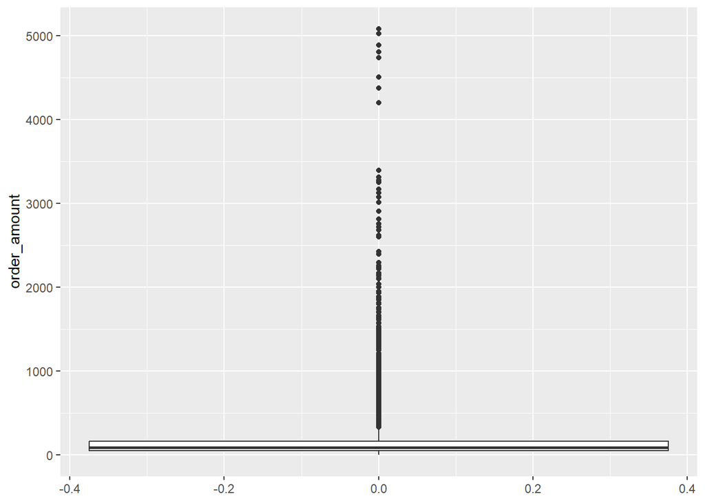

```r
ggplot(data, aes(y=order_amount)) +
 geom_boxplot()
```

##统计检验

```r
shapiro.test(sample(data$order_amount,500))
```

```
##
##  Shapiro-Wilk normality test
##
## data:  sample(data$order_amount, 500)
## W = 0.46869, p-value < 2.2e-16
```

Shapiro-Wilk 检验结果表明订单金额分布显著偏离正态分布， 符合消费数据常见的长尾分布特征。

##客户群消费差异(anova)

```r
anova_result <- aov(order_amount ~ segment, data=data)
summary(anova_result)
```

```
##               Df    Sum Sq Mean Sq F value Pr(>F)
## segment        2     10951    5476   0.064  0.938
## Residuals   7997 679601101   84982
```

采用单因素方差分析（ANOVA）比较不同客户群体（Occasional、Regular、Premium）的平均订单金额差异。结果显示组间差异不显著（F = 0.064，p = 0.938），说明在当前数据中，不同客户群体在单次消费金额上不存在显著差异。

##产品选择差异

```r
table_data <- table(data$segment, data$Name)
chisq.test(table_data)
```

```
##
##  Pearson's Chi-squared test
##
## data:  table_data
## X-squared = 4150.7, df = 4078, p-value = 0.2095
```

卡方检验结果表明不同客户群体在酒款选择上不存在显著差异。

##A/B Test 实验分析

```r
t.test(order_amount ~ experiment_group, data=data)
```

```
##
##  Welch Two Sample t-test
##
## data:  order_amount by experiment_group
## t = 3.1024, df = 7573.4, p-value = 0.001927
## alternative hypothesis: true difference in means between group A and group B is not equal to 0
## 95 percent confidence interval:
##   7.478341 33.149933
## sample estimates:
## mean in group A mean in group B
##        171.1371        150.8230
```

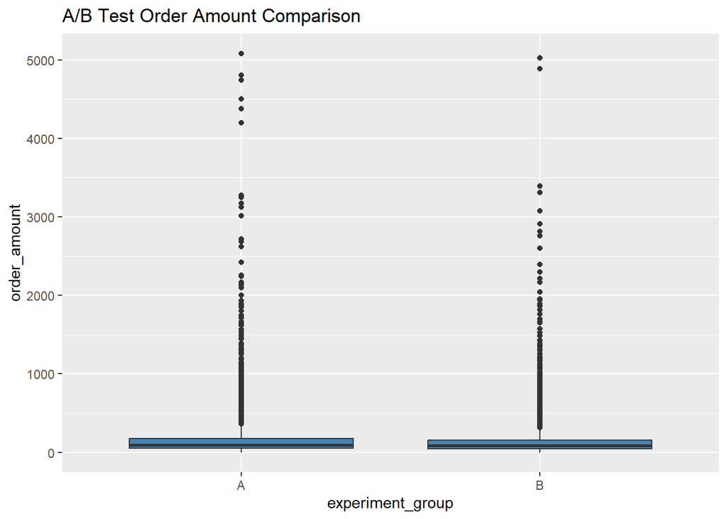

```r
ggplot(data, aes(experiment_group, order_amount)) +
  geom_boxplot(fill="steelblue") +
  labs(title="A/B Test Order Amount Comparison")
```

本研究通过 A/B Test 比较两种促销策略对销售表现的影响。实验将客户随机划分为两组，其中 A 组采用新的促销策略（推荐高评分红酒并提供折扣），B 组采用原有展示策略。通过 Welch t 检验比较两组订单金额，结果显示 A 组平均订单金额（171.14）显著高于 B 组（150.82）（p = 0.0019）。结果表明新的促销策略在提升客单价方面具有显著效果。

##结论与建议

综合以上分析，可以得到以下主要结论：

红酒订单金额呈明显长尾分布，大部分订单金额较低，但少量高价值订单对销售额贡献显著。

客户购买频率主要集中在中等水平，存在少量高频客户，具有较高的商业价值。

不同酒款之间销量差异明显，品牌和产品定位对销售表现具有重要影响。

数据中存在部分高金额异常订单，这些订单可能来自高端消费群体。

A/B Test 结果表明新的营销策略能够有效提升客单价。

月度销售趋势存在一定波动，可能受到季节性消费和市场需求变化的影响。

运营建议： 基于本次对波尔多红酒销售数据的统计分析与客户行为研究，可以提出以下运营优化建议：

1 提升高价值客户管理

数据分析表明，订单金额呈现明显的长尾分布，少数高金额订单对整体销售额贡献较大。这说明部分客户具有较高的消费能力和客户生命周期价值。

因此建议：

建立 VIP 客户管理体系

为高价值客户提供 会员折扣、专属推荐或限量酒款

通过个性化营销提高客户忠诚度

通过加强对高价值客户的运营，可以进一步提升整体销售收入。

2 优化产品推荐策略

销量排名显示，部分品牌酒款销量明显高于其他产品，说明消费者对特定品牌和酒庄具有较强偏好。

运营上可以：

将 销量较高的酒款作为主推产品

在首页推荐或促销活动中重点展示热门酒款

利用数据分析持续识别潜力产品

通过优化产品推荐策略，可以提高商品曝光率并促进销售增长。

3 利用 A/B Test 优化营销策略

A/B Test 结果显示，不同营销策略对订单金额存在显著影响，其中实验组策略能够有效提升客户客单价。

因此建议：

在更大范围内推广实验组营销策略

持续进行 数据驱动的营销实验（A/B Testing）

定期评估促销策略效果并进行优化

通过数据驱动的实验方法，可以不断提升营销效率。

4 提高客户复购率

客户购买频率分析表明，大多数客户的购买次数集中在中等水平，仍存在提升空间。

建议：

通过 优惠券、积分制度或会员奖励 提高复购率

针对低频客户进行定向营销

通过邮件或推荐系统提醒客户再次购买

提升客户复购率有助于稳定销售增长。

5 挖掘高端红酒市场

异常值分析显示，部分订单金额远高于平均水平，说明市场中存在一定比例的高端消费需求。

因此可以：

增加 高端红酒产品线

推出 限量酒款或收藏级酒款

针对高端客户开展定向营销

这有助于提升整体利润水平。

总结